# Data_Science_Capstone_Milestone_report

Anna Teplukhina

2022-07-19

## Overview

This milestone report is dedicated to analysis of the English text. Provided text files present a collection of blogs, news and twitter messages. With this exploratory analysis one can find the most common uni- (one word), bi-(two words) and trigrams (three words) presented in the text files. In order to perform this task, the text data are firstly cleaned.

It has been found that the most common unigrams are related to simple words or verbs, bigrams are more related to time events, trigrams are mostly about personal wishes and requests.

## Load libraries

Firstly, all nessesary libraries are loaded.

```r
library(ngram)
library(tm)
library(ggplot2)
library(RWeka)
```

## Load the data

Provided English text files are loaded from `.txt` files and related to blogs, news and twitter.

```r
blogs_path <- "./final/en_US/en_US.blogs.txt"
blogs_en <- readLines(blogs_path, skipNul = TRUE, warn= FALSE)

news_path <- "./final/en_US/en_US.news.txt"
news_en <- readLines(news_path, skipNul = TRUE, warn= FALSE)

twitter_path <- "./final/en_US/en_US.twitter.txt"
twitter_en <- readLines(twitter_path, skipNul = TRUE, warn= FALSE)
```

As a first look, one can compute size, length and nimber of words in each of the data sets.

```r
# Compute file size in Mib
en_size <- round(file.info(c(blogs_path, news_path, twitter_path))$size/1024^2)

# Compute length/line count
en_lines <- sapply(list(blogs_en, news_en, twitter_en),length)

# Compute number of words
en_words <- sapply(list(blogs_en, news_en, twitter_en), wordcount)

# Show summary table
data.frame(en_lines,en_size,en_words, row.names=c("blogs", "news", "twitter"))
```

```
##         en_lines en_size en_words
## blogs     899288     200 37334131
## news       77259     196  2643969
## twitter  2360148     159 30373583
```

The blogs contain more information/words than news and twitter. There are a lot of lines/twits in the twitter file. As expected, news are brief compared to blogs and twitter.

## Data cleaning

```r
# Sample size to build the predictive models
sample_size = 0.02 # 20%

# set seed to ensure reproducibility
set.seed(142)

# Sample data sets
blogs_sub <- sample(blogs_en, en_lines[1] * sample_size, replace = FALSE)
news_sub <- sample(news_en, en_lines[2] * sample_size, replace = FALSE)
twitter_sub <- sample(twitter_en, en_lines[3] * sample_size, replace = FALSE)
```

To clean the data, following elements will be removed:

- non-words like ASCII characters;
- URLs and emails;
- profanity words using a pre-loaded data file with a list of profanity words;
- English stop words like “is”, “a”, “the” and so on;
- numbers;
- punctuation marks;
- white space.

Also, all words will be converted to lowercase and text will be converted to a plain mode.

```r
# Load a .cvs file with profanity words
profanity <- read.csv("profanity.csv")
profanity <- profanity[,1]
# Add space instead of URLs and emails
add_space <- content_transformer(function(x, pattern) gsub(pattern, " ", x))

# Remove ASCII characters
blogs_clean <- iconv(blogs_sub, "latin1", "ASCII", sub="")
news_clean <- iconv(news_sub, "latin1", "ASCII", sub="")
twitter_clean <- iconv(twitter_sub, "latin1", "ASCII", sub="")

# Convert data to a single data set before cleaning
data_sub <- c(blogs_clean, news_clean, twitter_clean)
# Convert to use corpus and tm
data_corpus <- VCorpus(VectorSource(data_sub))

# Remove URLs and emails
data_clean <- tm_map(data_corpus, add_space, "https\\S*")
data_clean <- tm_map(data_clean, add_space, "(f|ht)tp(s?)://(.*)[.][a-z]+")
data_clean <- tm_map(data_clean, add_space, "@[^\\s]+")
data_clean <- tm_map(data_clean, add_space, "\\b[A-Z a-z 0-9._ - ]*[@](.*?)[.]{1,3} \\b")

# Convert words to lowercase
data_clean <- tm_map(data_clean, tolower)
# Remove profanity words
data_clean <- tm_map(data_clean, removeWords, profanity)
# Remove English stop words
data_clean <- tm_map(data_clean, removeWords, stopwords("en"))
# Remove numbers
data_clean <- tm_map(data_clean, removeNumbers)
# Remove punctuation marks
data_clean <- tm_map(data_clean, removePunctuation)
# Remove white spaces
data_clean <- tm_map(data_clean, stripWhitespace)
# Convert to a plain text
data_clean <- tm_map(data_clean, PlainTextDocument)
```

## Exploratory analysis

With the cleaned data set, one can do some exploratory analysis. Here the text data file is converted to a matrix to the distributions of word frequencies. Then 20 the most frequent words are shown vs their frequency.

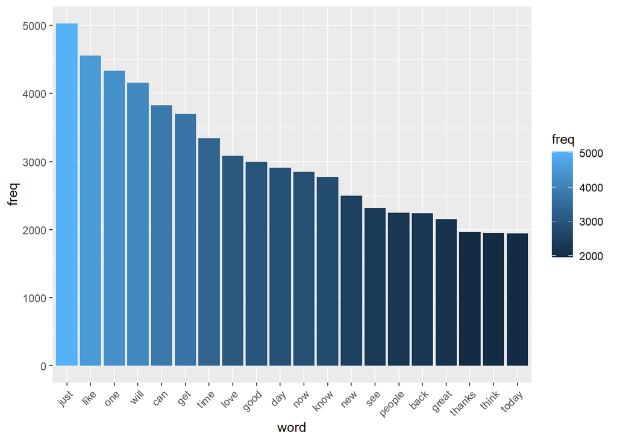

```r
# Convert text to a matrix
data_mtx <- TermDocumentMatrix(data_clean, control=list(minWordLength=1))
# Sort the matrix starting from the highest frequency
all_freq <- sort(rowSums(as.matrix(removeSparseTerms(data_mtx, 0.99))), decreasing = TRUE)
# Store to a data frame
words_freq <- data.frame(word = names(all_freq), freq = all_freq, row.names=NULL)

# Plot nn words vs frequencies
nn = 20
ggplot(data=words_freq[1:nn,], mapping=aes(x=word, y=freq, fill=freq)) +
  geom_bar(stat="identity") +
  scale_x_discrete(limits = words_freq[1:nn,1]) +
  theme(axis.text.x = element_text(hjust = 1.0, angle = 45))
```

One can see that for the selected sample the word `just` has the highest frequency about 5000.

## Tokenization and n-grams

As the last step of analysis, the frequency of uni-, bi- and trigrams is assessed. It will be done with a help of the `RWeka` library and `NGramTokenizer` function.

### Unigrams

We start with unigrams, i.e. analyse the presence of one-words. Below, 20 the most frequent unigrams are shown.

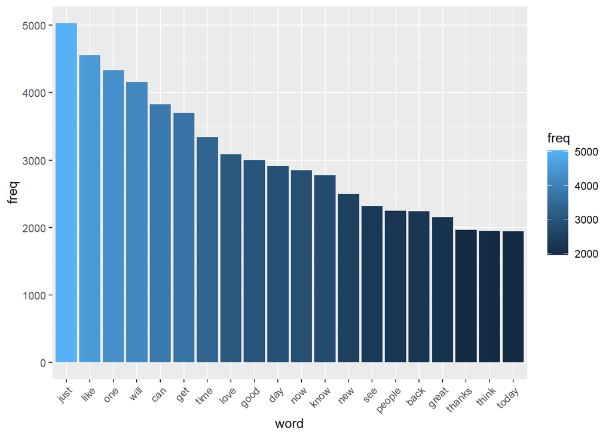

```r
# Set a Tokenizer function for unigrams
unigramTokenizer <- function(x) NGramTokenizer(x, Weka_control(min = 1, max = 1))
# Create the unigram matrix
uni_mtx <- TermDocumentMatrix(data_clean, control = list(tokenize = unigramTokenizer))
# Sort the matrix starting from the highest frequency
uni_freq <- sort(rowSums(as.matrix(removeSparseTerms(uni_mtx, 0.99))), decreasing = TRUE)
# Store to a data frame
uni_freq_df <- data.frame(word = names(uni_freq), freq = uni_freq, row.names=NULL)

# Plot nn words vs frequencies
nn = 20
ggplot(data=uni_freq_df[1:nn,], mapping=aes(x=word, y=freq, fill=freq)) +
  geom_bar(stat="identity") +
  scale_x_discrete(limits = uni_freq_df[1:nn,1]) +
  theme(axis.text.x = element_text(hjust = 1.0, angle = 45))
```

As expected, the created unigram matrix and the figure are identical to ones discussed in the exploratory analysis section, during which the single word frequency has been discussed. The most frequent unigrams are either simple words like “just” or “one”, or verbs “like”, “will”, “can”.

### Bigrams

Now, a similar approach can be applied to bigrams first and then to trigrams.

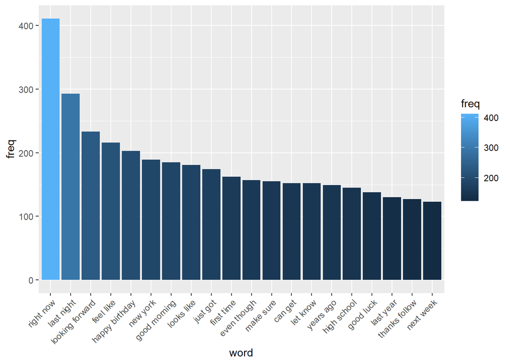

```r
# Set a Tokenizer function for bigrams
bigramTokenizer <- function(x) NGramTokenizer(x, Weka_control(min = 2, max = 2))
# Create the bigram matrix
bi_mtx <- TermDocumentMatrix(data_clean, control = list(tokenize = bigramTokenizer))
# Sort the matrix starting from the highest frequency
bi_freq <- sort(rowSums(as.matrix(removeSparseTerms(bi_mtx, 0.999))), decreasing = TRUE)
# Store to a data frame
bi_freq_df <- data.frame(word = names(bi_freq), freq = bi_freq, row.names=NULL)

# Plot nn words vs frequencies
nn = 20
ggplot(data=bi_freq_df[1:nn,], mapping=aes(x=word, y=freq, fill=freq)) +
  geom_bar(stat="identity") +
  scale_x_discrete(limits = bi_freq_df[1:nn,1]) +
  theme(axis.text.x = element_text(hjust = 1.0, angle = 45))
```

The most frequent bigrams are related to time: “right now”, “last might”, “looking forward”. Howerver, their frequency is almost 10 times lower than for unigrams.

### Trigrams

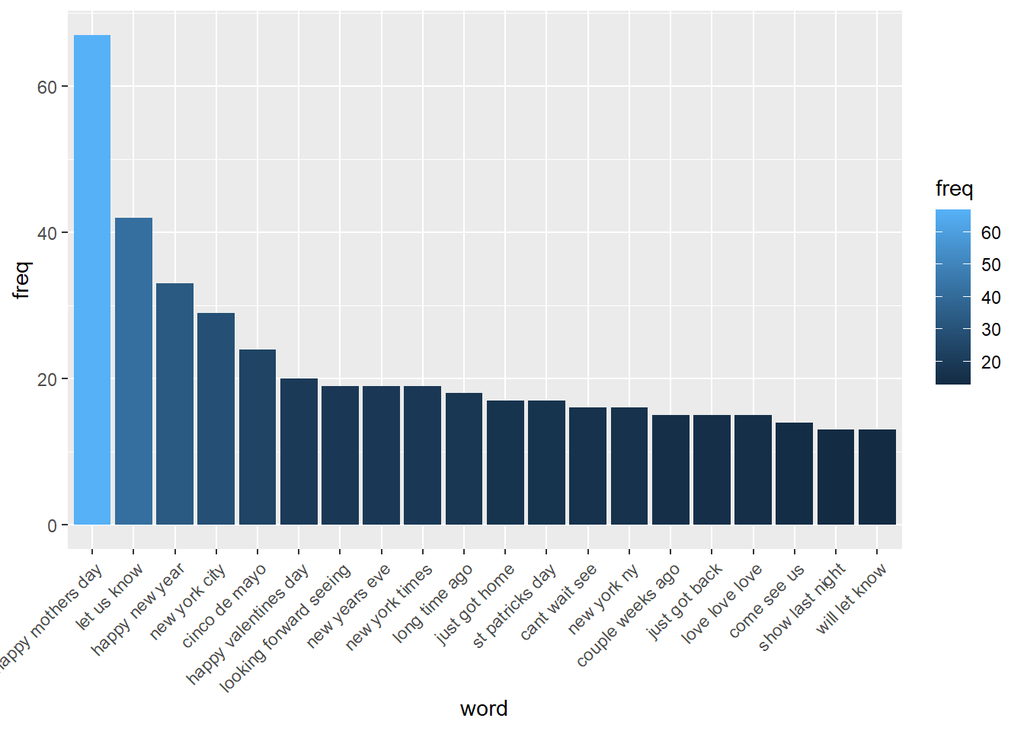

```r
# Set a Tokenizer function for trigrams
trigramTokenizer <- function(x) NGramTokenizer(x, Weka_control(min = 3, max = 3))
# Create the trigram matrix
tri_mtx <- TermDocumentMatrix(data_clean, control = list(tokenize = trigramTokenizer))
# Sort the matrix starting from the highest frequency
tri_freq <- sort(rowSums(as.matrix(removeSparseTerms(tri_mtx, 0.9999))), decreasing = TRUE)
# Store to a data frame
tri_freq_df <- data.frame(word = names(tri_freq), freq = tri_freq, row.names=NULL)

# Plot nn words vs frequencies
nn = 20
ggplot(data=tri_freq_df[1:nn,], mapping=aes(x=word, y=freq, fill=freq)) +
  geom_bar(stat="identity") +
  scale_x_discrete(limits = tri_freq_df[1:nn,1]) +
  theme(axis.text.x = element_text(hjust = 1.0, angle = 45))
```

## Next setps

The next step will be to build and train a numerical model that will be able to predict a next word (or 2-3 words) using a certain text as an input. This will be done for English language based on the discussed data analysis and created uni-, bi- and trigram matrices.

Then a user friendly Shiny app will be build using the developed predictive model. The main goals will be to make it reliable and not heavy or time consuming.